# Midterm

Cynthia Begay

Introduction: The COVID Racial Data Tracker is a volunteer organization launched from The Atlantic and was created in collaboration between the COVID Tracking Project and the Boston University Center for Antiracist Research. On April 12, 2020, this team began collecting race and ethnicity data from every state and eventually US territories. The tracker is updated twice per week. This dataset includes the total number of COVID cases and number of reported deaths due to COVID by race and ethnicity. While this is the only COVID related dataset I could find that reports race and ethnicity, the project acknowledges this is not a comprehensive dataset on race and ethnicity. As the COVID-19 pandemic unfolds, we are quickly learning about the disparity between race and COVID-19 cases. Currently Black, Indigenous, and Latinx people are most affected by COVID-19. As it stands, Black people have the highest disparity and are dying 2.3 times the rate of white people. American Indian and Alaska Native (AIAN) have the second highest disparity and currently have a death rate of 65 per 100,000 people compared to non-Hispanic white 43 per 100,000. Historically, AIAN communities are left out of the conversation when it comes to reporting data, especially emerging data like COVID-19 cases/deaths. The current national conversation around AIAN COVID disparities has been about (my tribe) the Navajo Nation, which at its worst, had the highest infection rate in the country (higher than New York in its peak). It is important to understand the rest of the landscape in the US when it comes to tribal communities as 70% of the AIAN population live in urban cities. I am using this project to explore AIAN COVID rates by state to understand where the highest disparities lie. The questions I will be exploring in this project are (1) which states reported the highest AIAN COVID cases in the US; (2) which states reported the highest AIAN COVID deaths in the US; (3) is there a correlation of AIAN COVID rates exclusive to states with a higher AIAN population per capita?

Methods The dataset was acquired through The COVID Tracking Project’s website https://covidtracking.com/race. Although an API version of the dataset was advertised on the website, the race related data was only available as a .csv file. Variables assessed were date, state, state code, total COVID cases, AIAN COVID cases, total deaths, AIAN deaths. Day, month, year, and state code variables were created in the csv file prior to reading in the data. The cases total variable was converted from a character variable to an integer in excel. Data wrangling Data variables were assessed using the str() function to understand the dataset variable classes; rows and columns were also assessed. The “State” variable is the only character variable; all other variable are integer variables. Before data exploration could be performed, the date variable was recreated into a date, month, and year variable in excel. All variables were checked to ensure data reflected between 4/12/2020 and 10/07/2020 when the data was retrieved. Data was limited to variables of interest: day, month, year, state, cases_AIAN, cases_total, deaths_AIAN, deaths_total. There are 2601 observations and 8 variables present. The head and tail of the dataset was assessed to ensure the data was read in properly. The cases total variable was validated against current reported data to ensure that the dataset did not exceed what has been reported by the CDC. Missing values were assessed with the dim function. Missing values in this dataset are both reflected as actual missing data not reported by the state, but also zero values. This has become problematic in this initial data wrangling, but I believe there may be a way to reconcile any “missing” data prior to the first case reported for each variable, which can be interpreted as a 0 or N/A value. A sub dataset was created to reflect the most recent values as of 10/04/2020 since Covid numbers reported in this dataset are addictive and not a reflection of daily updates.

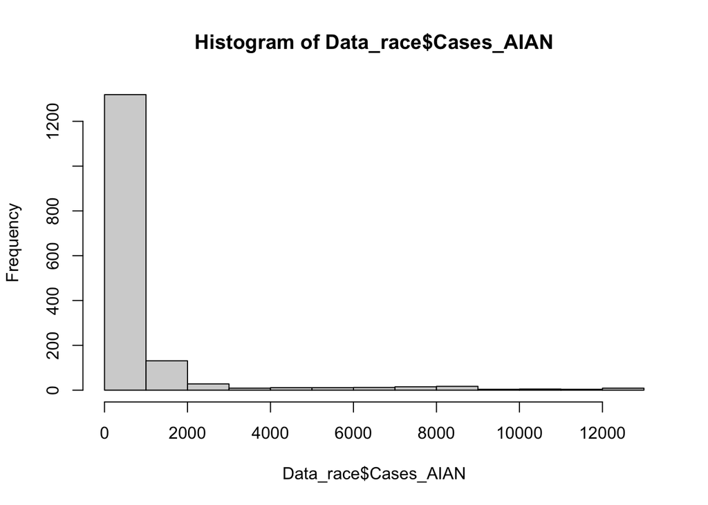

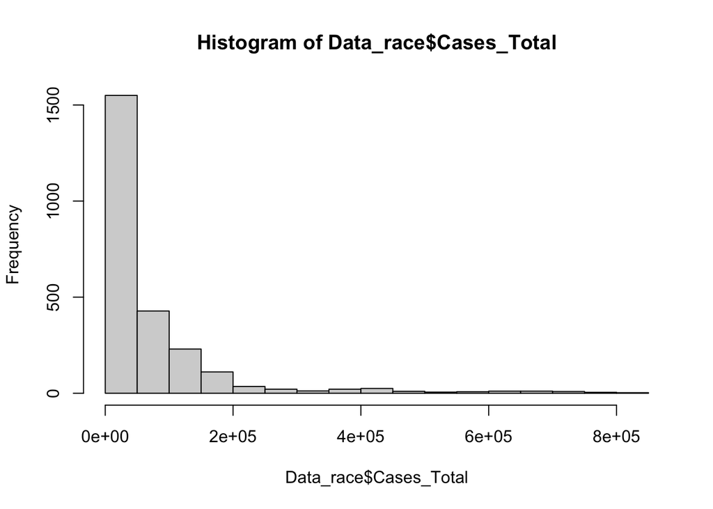

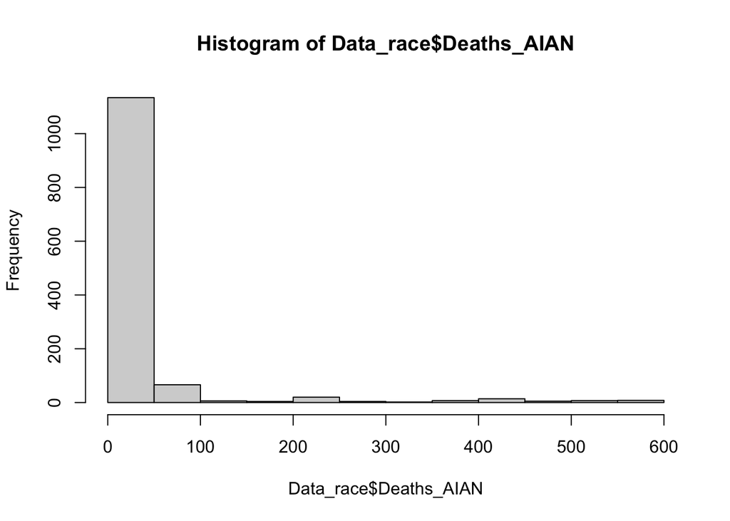

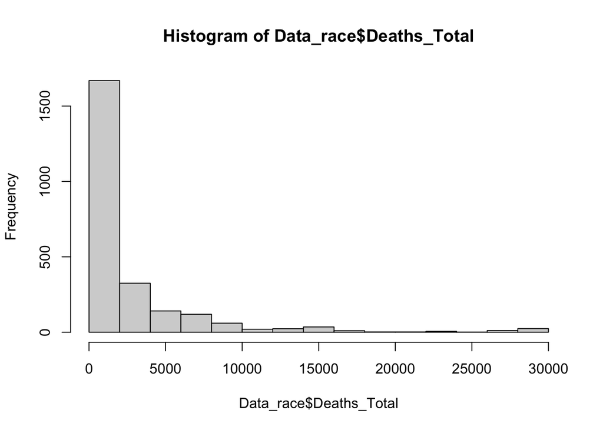

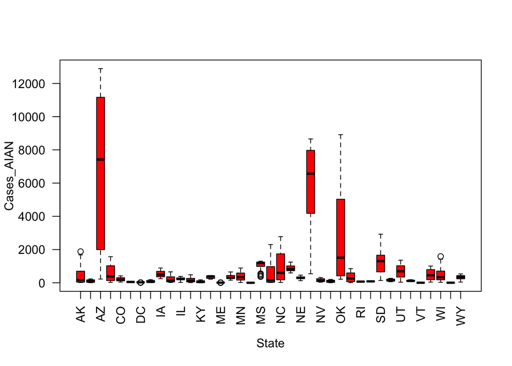

Preliminary Results

AIAN COVID Cases by State

AIAN Death Rates by State

[figure not shown]

[figure not shown]

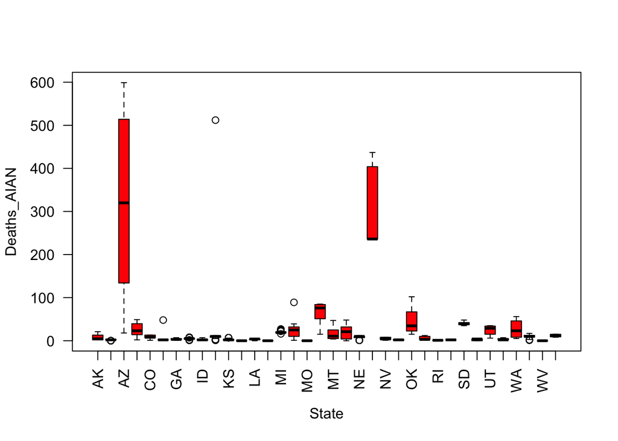

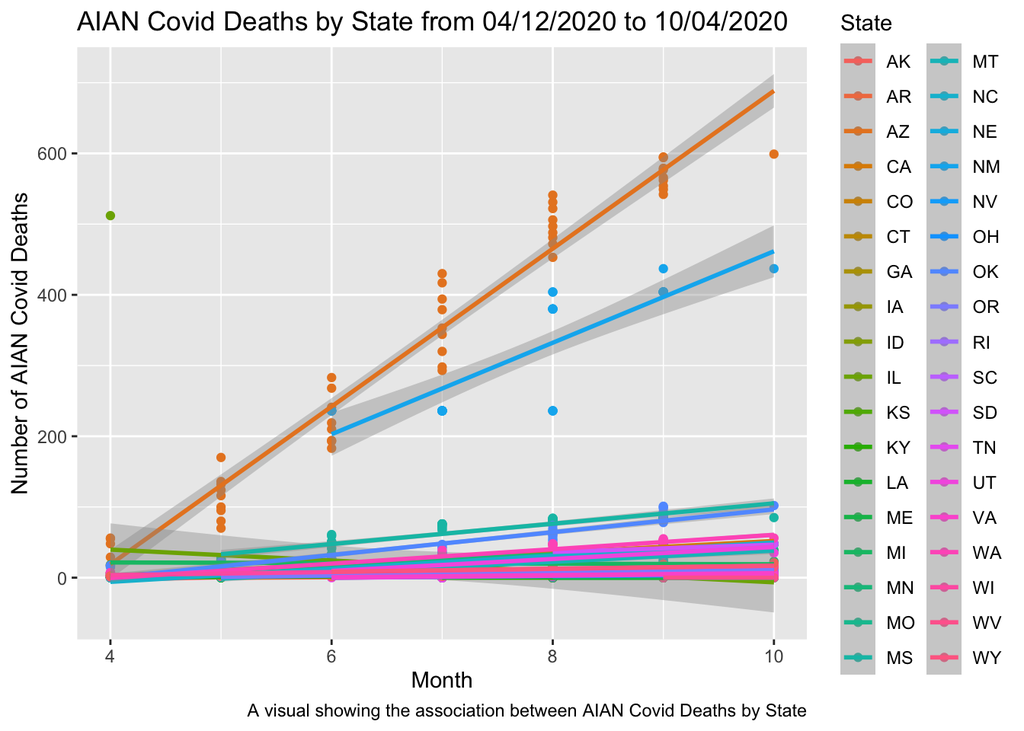

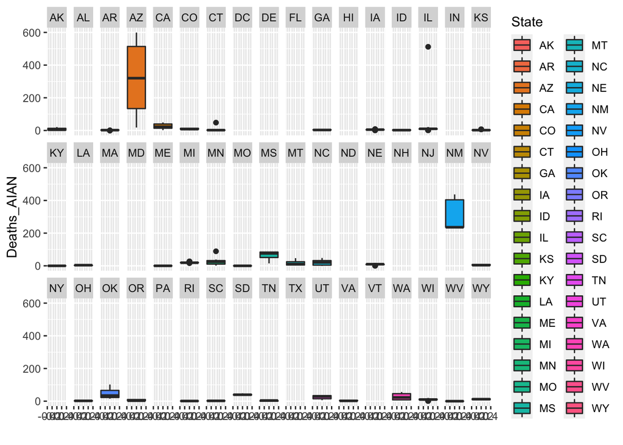

Summary table of AIAN COVID Cases and Deaths by State as of 10/04/2020.

| Date Month | Date Day | Date Year | State | State State_Code | Covid-19 Cases Cases_AIAN | Covid-19 Cases Cases_Total | Covid-19 Deaths Deaths_AIAN | Covid-19 Deaths Deaths_Total |
| --- | --- | --- | --- | --- | --- | --- | --- | --- |
| 10 | 4 | 2020 | AL | 1 | NA | 159169 | NA | 2558 |
| 10 | 4 | 2020 | AZ | 2 | 12893 | 220754 | 599 | 5706 |
| 10 | 4 | 2020 | AR | 3 | 231 | 87013 | 2 | 1425 |
| 10 | 4 | 2020 | CA | 4 | 1568 | 823729 | 48 | 16120 |
| 10 | 4 | 2020 | CO | 5 | 416 | 73076 | 13 | 1968 |
| 10 | 4 | 2020 | CT | 6 | 58 | 58297 | 2 | 4513 |
| 10 | 4 | 2020 | DE | 7 | NA | 21243 | NA | 645 |
| 10 | 4 | 2020 | DC | 8 | 38 | 15519 | NA | 631 |
| 10 | 4 | 2020 | FL | 9 | NA | 716459 | NA | 14845 |
| 10 | 4 | 2020 | GA | 10 | 175 | 322925 | 7 | 7162 |
| 10 | 4 | 2020 | ID | 11 | 657 | 43964 | 7 | 482 |
| 10 | 4 | 2020 | IL | 12 | 384 | 304280 | 12 | 9040 |
| 10 | 4 | 2020 | IN | 13 | NA | 125146 | NA | 3674 |
| 10 | 4 | 2020 | IA | 14 | 888 | 93388 | 4 | 1383 |
| 10 | 4 | 2020 | KS | 15 | 483 | 61111 | 7 | 698 |
| 10 | 4 | 2020 | KY | 16 | 174 | 72617 | 0 | 1209 |
| 10 | 4 | 2020 | LA | 17 | 437 | 169719 | 5 | 5577 |
| 10 | 4 | 2020 | ME | 18 | 14 | 5519 | 0 | 142 |
| 10 | 4 | 2020 | MD | 19 | NA | 127290 | NA | 3958 |
| 10 | 4 | 2020 | MA | 20 | NA | 134947 | NA | 9510 |
| 10 | 4 | 2020 | MI | 21 | 650 | 141271 | 23 | 7124 |
| 10 | 4 | 2020 | MN | 22 | 885 | 103826 | 39 | 2133 |
| 10 | 4 | 2020 | MS | 23 | 1299 | 100488 | 85 | 3013 |
| 10 | 4 | 2020 | MO | 24 | 0 | 132431 | 0 | 2173 |
| 10 | 4 | 2020 | MT | 25 | 2298 | 14635 | 47 | 187 |
| 10 | 4 | 2020 | NE | 26 | 460 | 47807 | 12 | 501 |
| 10 | 4 | 2020 | NV | 27 | 316 | 82100 | 8 | 1623 |
| 10 | 4 | 2020 | NH | 28 | NA | 8645 | NA | 443 |
| 10 | 4 | 2020 | NJ | 29 | NA | 208202 | NA | 16136 |
| 10 | 4 | 2020 | NM | 30 | 8658 | 30477 | 437 | 892 |
| 10 | 4 | 2020 | NY | 31 | NA | 464582 | NA | 28810 |
| 10 | 4 | 2020 | NC | 32 | 2778 | 217496 | 48 | 3634 |
| 10 | 4 | 2020 | ND | 33 | 1244 | 23550 | NA | 191 |
| 10 | 4 | 2020 | OH | 34 | 197 | 158907 | 4 | 4925 |
| 10 | 4 | 2020 | OK | 35 | 8914 | 91317 | 102 | 1052 |
| 10 | 4 | 2020 | OR | 36 | 851 | 34770 | 12 | 572 |
| 10 | 4 | 2020 | PA | 37 | NA | 163535 | NA | 8216 |
| 10 | 4 | 2020 | RI | 38 | 75 | 25076 | 1 | 1118 |
| 10 | 4 | 2020 | SC | 39 | NA | 151582 | NA | 3453 |
| 10 | 4 | 2020 | SD | 40 | 2923 | 24418 | 48 | 248 |
| 10 | 4 | 2020 | TN | 41 | 267 | 201210 | 4 | 2577 |
| 10 | 4 | 2020 | TX | 42 | NA | 765894 | NA | 16025 |
| 10 | 4 | 2020 | UT | 43 | 1358 | 77618 | 35 | 478 |
| 10 | 4 | 2020 | VT | 44 | 2 | 1785 | NA | 58 |
| 10 | 4 | 2020 | VA | 45 | 185 | 151870 | 7 | 3273 |
| 10 | 4 | 2020 | WA | 46 | 1007 | 89874 | 56 | 2142 |
| 10 | 4 | 2020 | WV | 47 | 4 | 16628 | 0 | 358 |
| 10 | 4 | 2020 | WI | 48 | 1588 | 139928 | 17 | 1388 |
| 10 | 4 | 2020 | WY | 49 | 532 | 6504 | 15 | 53 |
| 10 | 4 | 2020 | HI | 52 | NA | 12804 | NA | 156 |
| 10 | 4 | 2020 | AK | 54 | 1882 | 9376 | 21 | 58 |